# Understanding Market Shocks Through Time Series Analysis

A Market Analytics View of COVID-19 and Stock Market Returns

Devansh Sachar

2026-05-27

## Why Time Series Matters

Financial markets are **sequential** — prices today depend on prices yesterday. Analysts cannot study them like one-time observations.

- How prices **evolve** over time
- How **risk changes** across periods
- When **unusual shocks** happen
- Whether market **behavior shifts** after events

CASE STUDY

COVID-19

The defining market shock of our era — a perfect case study in time series methods.

4×

volatility spike

−34%

S&P 500 drop

## What Is Time Series Analysis?

### 📊 What It Studies

Data ordered through time — each observation linked to a specific date or period.  
Examples: stock prices, returns, inflation, sales, exchange rates, website traffic.

### 🎯 Main Goal

Identify **patterns**, **changes**, and **unusual behavior** — then translate those into actionable decisions.

### 🔑 Key Questions

- Is this series trending?
- Did behavior change at a specific date?
- Are recent values unusually extreme?

### 🏦 Why Finance?

Risk is not constant. Asset prices evolve through time. Static analysis misses all of this.

**Core idea:** A number without a timestamp is just a number. Time series analysis turns timestamps into insight.

## Simulated Market Index: 2018 – 2022

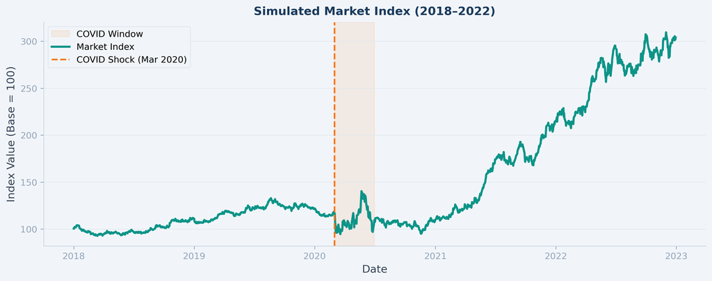

## Prices vs Returns: What Do We Measure?

### Stock Prices

- Show the **level** of the market
- Non-stationary — tend to drift upward
- Hard to compare across stocks
- Don’t directly reveal risk
- Affected by splits and dividends

### Stock Returns ✓ Preferred

- Show **% change** from period to period
- Stationary — suitable for statistics
- Comparable across stocks and time
- Directly measure **risk** via variance
- Foundation of modern portfolio theory

R<sub>t</sub> = ( Price<sub>t</sub> − Price<sub>t−1</sub> ) / Price<sub>t−1</sub>

## Daily Returns Over Time

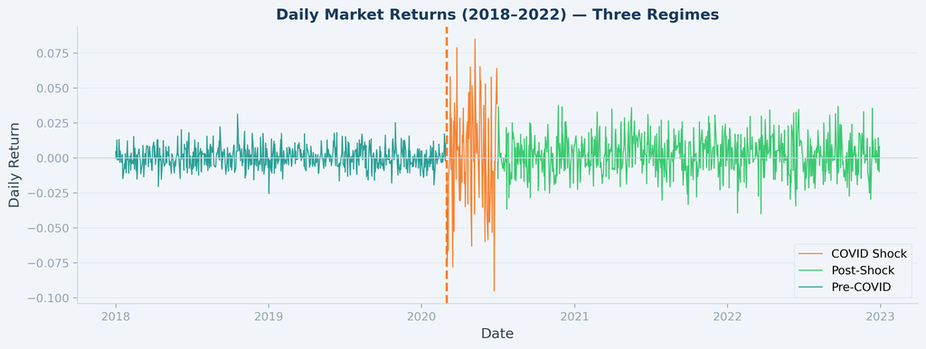

**Pre-COVID**  
Stable, tight returns  
σ ≈ 0.8% / day

**Post-Shock**  
Elevated but calmer  
σ ≈ 1.4% / day

## Concept 1: Volatility

### 📐 Definition

The **standard deviation** of returns over a rolling window. Measures how much prices fluctuate around their average.

### ⚠️ High Vol Means

- Larger gains *and* losses
- More uncertain forecasts
- Higher risk premiums
- Harder to hedge

### 🏦 Who Uses It

**Banks** (VaR models), **hedge funds** (position sizing), **regulators** (systemic risk), **options traders** (implied vol).

### 📏 How We Measure

30-day rolling window standard deviation of daily returns. The standard for short-term market risk monitoring.

## 30-Day Rolling Volatility

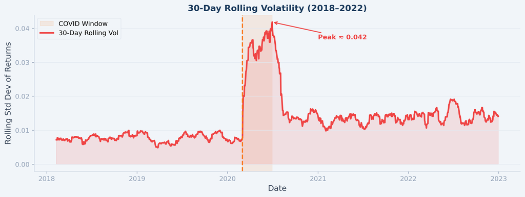

## Comparing Market Periods

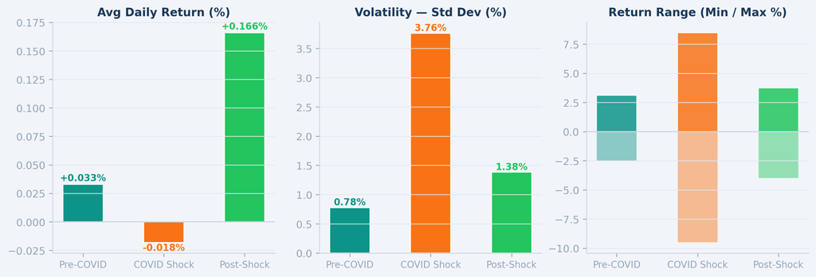

## Concept 2: Structural Break

### 📖 Definition

A structural break occurs when the **statistical properties** of a time series — its mean, variance, or relationships — change **permanently** at a specific point in time.

After a break, models fitted on pre-break data give **poor forecasts** and misleading risk estimates.

## Return Distribution: Wider Tails in a Crisis

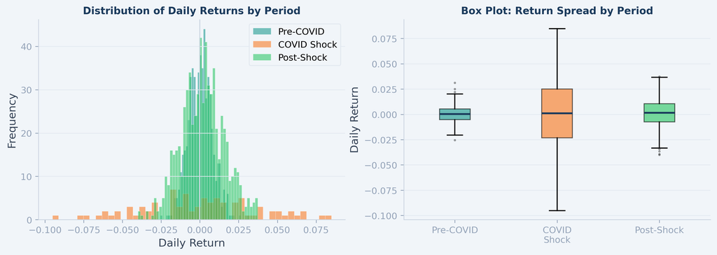

**COVID Shock:** much wider histogram + longer box plot whiskers = more extreme outcomes both ways. This is **fat tails** — rare catastrophic events becoming temporarily common.

## Anomaly Detection: Finding the Outliers

1

#### Compute Global Mean & Std Dev

Calculate μ (mean) and σ (std dev) across the full return series

2

#### Apply the 3-Sigma Rule

Flag any day where |R<sub>t</sub> − μ| > 3σ as an anomaly

3

#### Identify & Investigate

Examine flagged dates — most will cluster near the COVID shock window

Anomaly if: |R<sub>t</sub> − μ| > 3σ

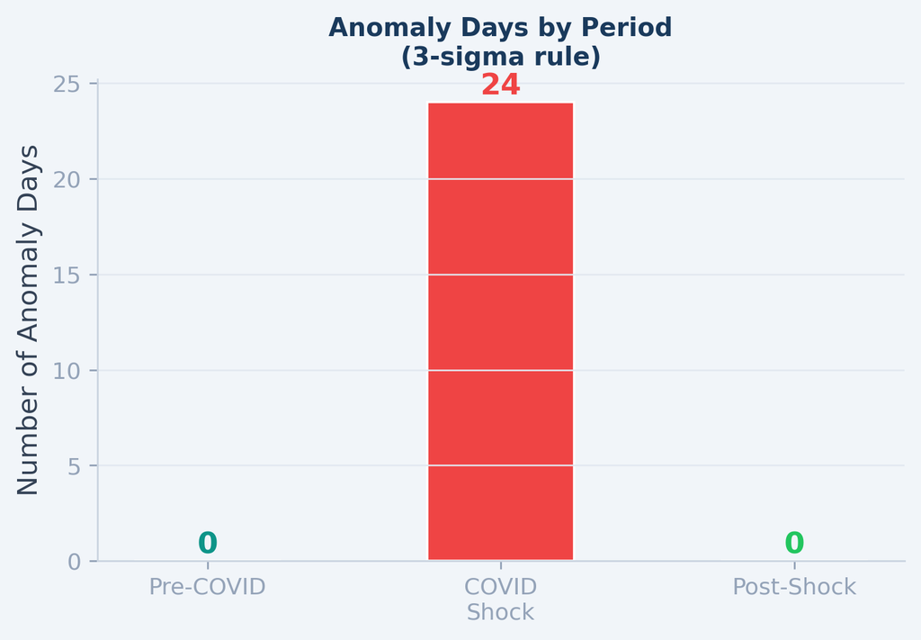

## Anomaly Map: Where Did They Occur?

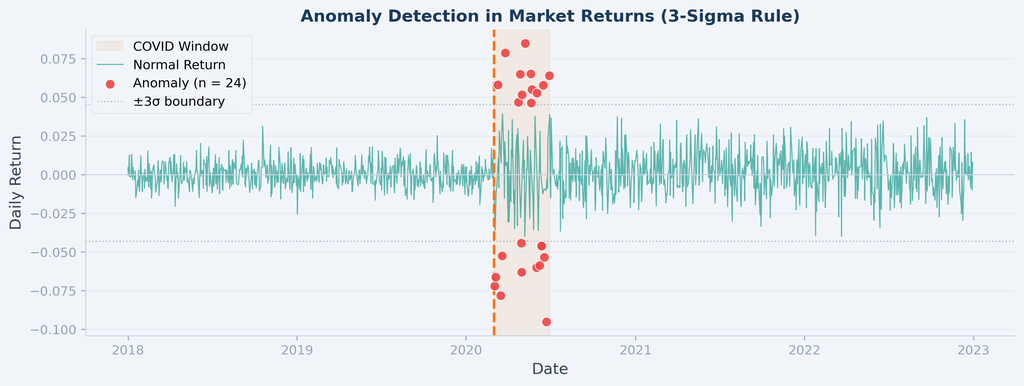

## Why This Matters for Business

### 🏦 Banks & Risk Managers

Recalibrate Value-at-Risk models after vol spikes. Pre-COVID models dramatically underestimated tail risk during the shock.

### 📈 Investors

Rebalance using rolling volatility as a signal. High-vol regimes call for defensive allocations and hedging strategies.

### 🏭 CFOs & Firms

Plan working capital around elevated uncertainty. Structural breaks can persist months before markets normalise.

### 🔍 Analysts

Anomaly detection as an early-warning system. Flagging 3-sigma events gives decision-makers critical lead time.

**Core message:** Market analytics is not only about predicting prices — it is about **measuring**, **monitoring**, and **communicating risk** in a constantly changing world.

## Key Takeaways

01 Returns Over Prices

02 Volatility = Risk

The **4× spike** in rolling volatility during COVID is the clearest, most actionable signal in the data. Volatility regimes are real and measurable.

03 Structural Breaks Are Real

COVID-19 created a genuine **regime change**. Models trained on pre-crisis data failed immediately. Detecting the break date is step one.

## Final Conclusion

COVID-19 showed that markets can shift **quickly and completely** during major events. Time series analysis gives us the tools to see those shifts clearly, measure them precisely, and respond intelligently.

By studying **returns** rather than prices, measuring **rolling volatility**, identifying **structural breaks**, and flagging **anomalies** — analysts gain a real decision-making edge.

Returns

over raw prices

Volatility

as the risk signal

Decisions

not just charts

Devansh Sachar · MGTF 406 — Behavioral Finance · Rady School of Management, UC San Diego · May 2026